# Regression Project

#### Multivariate linear regression

#### Preparing the data

```python
# Create test and train datasets
# This is again very similar, but now we include more columns in the predictors
# Include all columns from data in X except alcohol & quality
X = dataset2.drop(["CODA_STAND"],axis=1)
# Create constants for X, so the model knows its bounds
X = sm.add_constant(X)
y = dataset2[["CODA_STAND"]]
# Split the data
X_train, X_test, y_train, y_test = train_test_split(X, y, test_size = 0.25, random_state = 123)
```

```python
# We can use almost identical code to create the third model, because it is the same algorithm, just different inputs
# Create the model
model3 = sm.OLS(y_train, X_train)
# Fit the model
model3_results = model3.fit()
```

```python
# Evaluate the model
model3_results.summary()
```

OLS Regression Results

| Dep. Variable: | CODA_STAND | R-squared: | 0.845 |
| --- | --- | --- | --- |
| Model: | OLS | Adj. R-squared: | 0.843 |
| Method: | Least Squares | F-statistic: | 487.1 |
| Date: | Mon, 12 Aug 2019 | Prob (F-statistic): | 0.00 |
| Time: | 19:48:07 | Log-Likelihood: | 1713.6 |
| No. Observations: | 903 | AIC: | -3405. |
| Df Residuals: | 892 | BIC: | -3352. |
| Df Model: | 10 |  |  |
| Covariance Type: | nonrobust |  |  |

|  | coef | std err | t | P>\|t\| | [0.025 | 0.975] |
| --- | --- | --- | --- | --- | --- | --- |
| const | -0.1355 | 0.097 | -1.397 | 0.163 | -0.326 | 0.055 |
| TGT | 0.9220 | 0.111 | 8.295 | 0.000 | 0.704 | 1.140 |
| CODA | 0.3064 | 0.017 | 17.795 | 0.000 | 0.273 | 0.340 |
| WASTE_STAND | -0.5604 | 0.018 | -30.297 | 0.000 | -0.597 | -0.524 |
| WASTE | 0.0404 | 0.005 | 8.270 | 0.000 | 0.031 | 0.050 |
| DEMAND | -8.965e-07 | 1.82e-07 | -4.934 | 0.000 | -1.25e-06 | -5.4e-07 |
| FORECAST | 5.965e-07 | 1.19e-07 | 5.022 | 0.000 | 3.63e-07 | 8.3e-07 |
| STOCKING_POINTS | 1.224e-06 | 3.66e-07 | 3.347 | 0.001 | 5.06e-07 | 1.94e-06 |
| LOST_SALES | 3.569e-07 | 4.32e-07 | 0.825 | 0.409 | -4.92e-07 | 1.21e-06 |
| WASTE_UNITS | -4.884e-06 | 3.61e-07 | -13.511 | 0.000 | -5.59e-06 | -4.17e-06 |
| SALES_UNITS | 2.201e-07 | 1.27e-07 | 1.736 | 0.083 | -2.88e-08 | 4.69e-07 |

| Omnibus: | 171.298 | Durbin-Watson: | 2.058 |
| --- | --- | --- | --- |
| Prob(Omnibus): | 0.000 | Jarque-Bera (JB): | 2635.909 |
| Skew: | 0.364 | Prob(JB): | 0.00 |
| Kurtosis: | 11.338 | Cond. No. | 1.64e+07 |

Warnings:  
[1] Standard Errors assume that the covariance matrix of the errors is correctly specified.  
[2] The condition number is large, 1.64e+07. This might indicate that there are  
strong multicollinearity or other numerical problems.

```python
# Use our new model to make predictions
y_pred = model3_results.predict(X_test)
```

```
Text(0,0.5,'Predicted')
```

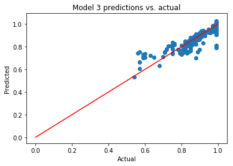

```python
# Plot the predictions
# Build a scatterplot
plt.scatter(y_test, y_pred)
# Add a line for perfect correlation
plt.plot([x for x in range(0,2)],[x for x in range(0,2)], color='red')
# Label it nicely
plt.title("Model 3 predictions vs. actual")
plt.xlabel("Actual")
plt.ylabel("Predicted")
```

We've now got a much closer match between our data and our predictions, and we can see that the shape of the data points is even closer and clustered around the red line.

```python
# Define a function to check the RMSE
def rmse(predictions, targets):
    return np.sqrt(((predictions - targets) ** 2).mean())
```

```python
# Get predictions from model
y_pred = model3_results.predict(X_test)
# put predictions & actual into a dataframe
matches = pd.DataFrame(y_test)
matches.rename(columns = {'CODA_STAND':'actual'}, inplace=True)
matches["predicted"] = y_pred
rmse(matches["actual"], matches["predicted"])
```

```
0.044011947617091964
```

Let's remove LOST_SALES and SALES_UNITS, as they don’t seem to be useful predictors. This should hopefully reduce the noise and let us make more accurate predictions.

```python
# Create test and train datasets
# This is again very similar, but now we include more columns in the predictors
# Include all columns from data in X except CODA_STAND, LOST_SALES & SALES_UNITS
X = dataset2.drop(["CODA_STAND","LOST_SALES","SALES_UNITS"],axis=1)
# Create constants for X, so the model knows its bounds
X = sm.add_constant(X)
y = dataset2[["CODA_STAND"]]
# Split the data
X_train, X_test, y_train, y_test = train_test_split(X, y, test_size = 0.25, random_state = 123)
```

```python
# Create the fourth model
model4 = sm.OLS(y_train, X_train)
# Fit the model
model4_results = model4.fit()
# Evaluate the model
model4_results.summary()
```

OLS Regression Results

| Dep. Variable: | CODA_STAND | R-squared: | 0.845 |
| --- | --- | --- | --- |
| Model: | OLS | Adj. R-squared: | 0.843 |
| Method: | Least Squares | F-statistic: | 607.7 |
| Date: | Mon, 12 Aug 2019 | Prob (F-statistic): | 0.00 |
| Time: | 19:48:08 | Log-Likelihood: | 1712.0 |
| No. Observations: | 903 | AIC: | -3406. |
| Df Residuals: | 894 | BIC: | -3363. |
| Df Model: | 8 |  |  |
| Covariance Type: | nonrobust |  |  |

|  | coef | std err | t | P>\|t\| | [0.025 | 0.975] |
| --- | --- | --- | --- | --- | --- | --- |
| const | -0.1964 | 0.083 | -2.352 | 0.019 | -0.360 | -0.033 |
| TGT | 0.9927 | 0.098 | 10.182 | 0.000 | 0.801 | 1.184 |
| CODA | 0.3048 | 0.017 | 18.331 | 0.000 | 0.272 | 0.337 |
| WASTE_STAND | -0.5638 | 0.018 | -30.660 | 0.000 | -0.600 | -0.528 |
| WASTE | 0.0408 | 0.005 | 8.372 | 0.000 | 0.031 | 0.050 |
| DEMAND | -6.995e-07 | 1.41e-07 | -4.950 | 0.000 | -9.77e-07 | -4.22e-07 |
| FORECAST | 5.276e-07 | 1.12e-07 | 4.705 | 0.000 | 3.08e-07 | 7.48e-07 |
| STOCKING_POINTS | 1.304e-06 | 3.61e-07 | 3.615 | 0.000 | 5.96e-07 | 2.01e-06 |
| WASTE_UNITS | -4.712e-06 | 3.49e-07 | -13.504 | 0.000 | -5.4e-06 | -4.03e-06 |

| Omnibus: | 176.115 | Durbin-Watson: | 2.047 |
| --- | --- | --- | --- |
| Prob(Omnibus): | 0.000 | Jarque-Bera (JB): | 2641.046 |
| Skew: | 0.411 | Prob(JB): | 0.00 |
| Kurtosis: | 11.338 | Cond. No. | 1.33e+07 |

Warnings:  
[1] Standard Errors assume that the covariance matrix of the errors is correctly specified.  
[2] The condition number is large, 1.33e+07. This might indicate that there are  
strong multicollinearity or other numerical problems.

As we can the R-Squared value has not changed, this means the variables were not important or relevant predictors.

```
Text(0,0.5,'Predicted')
```

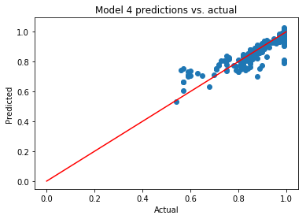

```python
# Plot the predictions

# Build a scatterplot
plt.scatter(y_test, y_pred)

# Add a line for perfect correlation
plt.plot([x for x in range(0,2)],[x for x in range(0,2)], color='red')

# Label it nicely
plt.title("Model 4 predictions vs. actual")
plt.xlabel("Actual")
plt.ylabel("Predicted")
```

```python
# Define a function to check the RMSE
def rmse(predictions, targets):
    return np.sqrt(((predictions - targets) ** 2).mean())
```

```python
# get predictions from model4
y_pred = model4_results.predict(X_test)

# put predictions & actual into a dataframe
matches = pd.DataFrame(y_test)
matches.rename(columns = {'CODA_STAND':'actual'}, inplace=True)
matches["predicted"] = y_pred

rmse(matches["actual"], matches["predicted"])
```

```
0.04414493364847748
```

Looking at the RMSE of the model we can see that the value has not changed at two decimal place and is still 0.04.